# Analyse épidémiologique des maladies tropicales négligées

Situation, endémicité et évolution des indicateurs GNARF

Application TVD

20/10/2026

# 1 Objet et méthode

Ce rapport applique les trois niveaux du plan d’analyse : **A. carte d’endémicité**, **B. fiche régionale par maladie** et **C. profil pays**. Il lit la table correspondant au paramètre `source` dans la base SQLite du projet (`input/tvd_datawarehouse.sqlite`). Les résultats se mettent à jour à chaque rendu du document.

La variation entre les années extrêmes est calculée ainsi :

$$\text{Variation (\%)} = \frac{\text{valeur année maximale} -
\text{valeur année minimale}}{\text{valeur année minimale}} \times 100$$

Les valeurs agrégées privilégient les lignes **All Ages + Unknown/Both sexes**. Les pays doivent avoir une observation aux deux années comparées. Les catégories d’âge ou de sexe ne sont pas additionnées au total correspondant.

## 1.1 Portée des indicateurs

Les indicateurs du fichier sont des **comptes déclarés**. Sans dénominateurs de population, ce rapport ne calcule pas de taux de prévalence, d’incidence ou de mortalité. Sans nombre de personnes éligibles au traitement, il ne calcule pas la couverture thérapeutique. Une variation de déclarations peut refléter un changement de situation sanitaire, de surveillance ou de complétude des rapports.

# 2 A. Endémicité

**Filtres** — Source : GNARF ; maladie : Buruli ulcer ; année rapportée (`period`) : 2025.

La légende des codes appliquée dans le rapport est :

Légende d’endémicité

| Code | Statut |
| --- | --- |
| 4 | Yes, country is not endemic but reports for surveillance/zero reporting |
| 3 | No, country is known to be endemic but no surveillance system exists or data are not available |
| 2 | No, country is not endemic and will not report for this disease |
| 1 | Yes, country is endemic (report required) |
| 5 | Never endemic |
| — | Statuts multiples (plusieurs statuts pour le pays et la période retenue) |

## 2.1 Heatmap par pays

| Pays | Statut |
| --- | --- |
| Angola | Yes, country is endemic (report required) |
| Benin | Yes, country is endemic (report required) |
| Botswana | No, country is not endemic and will not report for this disease |
| Burkina Faso | Yes, country is endemic (report required) |
| Burundi | No, country is not endemic and will not report for this disease |
| Cabo Verde | No, country is not endemic and will not report for this disease |
| Cameroon | Yes, country is endemic (report required) |
| Chad | No, country is not endemic and will not report for this disease |
| Congo | Yes, country is endemic (report required) |
| Côte d'Ivoire | Yes, country is endemic (report required) |

[output cut: 24 more lines]

## 2.2 Répartition des statuts

Statuts déclarés en 2025

| disease | endemicity_cat | pays |
| --- | --- | --- |
| Buruli ulcer | Yes, country is not endemic but reports for surveillance/zero reporting | 1 |
| Buruli ulcer | No, country is known to be endemic but no surveillance system exists or data are not available | 2 |
| Buruli ulcer | No, country is not endemic and will not report for this disease | 17 |
| Buruli ulcer | Yes, country is endemic (report required) | 14 |

# 3 B. Fiche régionale par maladie

Les tableaux annuels décrivent les comptes par indicateur et le nombre de pays déclarants. Les totaux de **différents indicateurs ne sont pas additionnés entre eux**, car ils peuvent représenter des mesures distinctes ou des catégories qui se recouvrent.

## 3.1 Couverture des données par domaine et année

Couverture descriptive — elle varie selon les années et les domaines

| domain | year | indicateurs | pays_declarants | lignes |
| --- | --- | --- | --- | --- |
| Endémicité | 2024 | 29 | 43 | 967 |
| Endémicité | 2025 | 29 | 37 | 914 |
| Incidence | 2024 | 32 | 35 | 972 |
| Incidence | 2025 | 34 | 34 | 1143 |
| Mortalité | 2024 | 10 | 28 | 339 |
| Mortalité | 2025 | 11 | 29 | 346 |
| Prevalence | 2024 | 26 | 31 | 515 |
| Prevalence | 2025 | 28 | 27 | 576 |
| Prise en charge | 2024 | 9 | 20 | 156 |
| Prise en charge | 2025 | 8 | 21 | 159 |

## 3.2 Situation et changements : prévalence, incidence, mortalité et prise en charge

Les résultats de chaque domaine sont calculés séparément. La comparaison entre les années minimale et maximale utilise uniquement les pays ayant déclaré aux deux périodes.

### 3.2.1 Prévalence

Aucune comparaison appariée disponible pour ce domaine.

### 3.2.2 Incidence

Comparaison 2024 à 2025

| Maladie | Indicateur | Pays communs | Année minimale | Valeur minimale | Année maximale | Valeur maximale | Écart | Variation |
| --- | --- | --- | --- | --- | --- | --- | --- | --- |
| Leishmaniasis | 1.1 Leishmaniasis (ACL) new clinically-confirmed cases | 3 | 2024 | 44 | 2025 | 219 | 175 | 397.7% |
| Leishmaniasis | 1.1 Leishmaniasis (ACL) new probable cases | 3 | 2024 | 44 | 2025 | 219 | 175 | 397.7% |
| Chikungunya | Chikungunya new suspected cases | 3 | 2024 | 37 | 2025 | 156 | 119 | 321.6% |
| Noma | Noma new clinically-confirmed cases - stage 3 | 1 | 2024 | 34 | 2025 | 107 | 73 | 214.7% |
| Buruli ulcer | Buruli ulcer new laboratory-confirmed cases by PCR | 5 | 2024 | 65 | 2025 | 168 | 103 | 158.5% |
| Noma | Noma new clinically-confirmed cases - stage 5 | 1 | 2024 | 22 | 2025 | 50 | 28 | 127.3% |
| Buruli ulcer | Buruli ulcer new suspected cases | 6 | 2024 | 654 | 2025 | 1409 | 755 | 115.4% |
| Buruli ulcer | Buruli ulcer new clinical cases | 4 | 2024 | 566 | 2025 | 1125 | 559 | 98.8% |
| Dengue | Dengue new confirmed cases | 4 | 2024 | 1642 | 2025 | 24 | -1618 | -98.5% |
| Noma | Noma new clinically-confirmed cases - stage 2 | 2 | 2024 | 30 | 2025 | 54 | 24 | 80.0% |
| Schistosomiasis | Schistosomiasis new confirmed cases - Intestinal | 7 | 2024 | 8427 | 2025 | 2134 | -6293 | -74.7% |
| Dracunculiasis | Dracunculiasis new probable cases | 4 | 2024 | 7 | 2025 | 2 | -5 | -71.4% |
| Noma | Noma new clinically-confirmed cases - stage 4 | 1 | 2024 | 34 | 2025 | 50 | 16 | 47.1% |
| Dengue | Dengue new probable case | 1 | 2024 | 3 | 2025 | 2 | -1 | -33.3% |
| Human African trypanosomiasis (gambiense) | gHAT new confirmed cases | 5 | 2024 | 311 | 2025 | 220 | -91 | -29.3% |
| Tungiasis | Tungiasis new clinical cases | 1 | 2024 | 8100 | 2025 | 6013 | -2087 | -25.8% |
| Noma | Noma new clinically-confirmed cases - stage 1 | 2 | 2024 | 159 | 2025 | 137 | -22 | -13.8% |
| Scabies | Scabies new clinical cases | 8 | 2024 | 408258 | 2025 | 368437 | -39821 | -9.8% |
| Leprosy | Leprosy new MB cases | 18 | 2024 | 3850 | 2025 | 4081 | 231 | 6.0% |
| Leprosy | Leprosy new unclassified cases | 11 | 2024 | 3038 | 2025 | 2917 | -121 | -4.0% |
| Leprosy | Leprosy new PB cases | 17 | 2024 | 1261 | 2025 | 1212 | -49 | -3.9% |
| Schistosomiasis | Schistosomiasis new confirmed cases - Urogenital | 12 | 2024 | 211503 | 2025 | 205079 | -6424 | -3.0% |
| Leprosy | Leprosy new cases with grade 2 disability | 15 | 2024 | 1005 | 2025 | 980 | -25 | -2.5% |
| Chikungunya | Chikungunya new confirmed cases | 2 | 2024 | 0 | 2025 | 0 | 0 | Non calculable (valeur initiale nulle) |
| Chikungunya | Chikungunya new probable cases | 2 | 2024 | 0 | 2025 | 0 | 0 | Non calculable (valeur initiale nulle) |
| Dengue | Severe dengue new confirmed cases | 2 | 2024 | 0 | 2025 | 0 | 0 | Non calculable (valeur initiale nulle) |
| Scabies | Scabies new lab-confirmed cases | 3 | 2024 | 0 | 2025 | 0 | 0 | Non calculable (valeur initiale nulle) |
| Schistosomiasis | Schistosomiasis new confirmed cases - Genital | 2 | 2024 | 0 | 2025 | 0 | 0 | Non calculable (valeur initiale nulle) |

### 3.2.3 Mortalité

Comparaison 2024 à 2025

| Maladie | Indicateur | Pays communs | Année minimale | Valeur minimale | Année maximale | Valeur maximale | Écart | Variation |
| --- | --- | --- | --- | --- | --- | --- | --- | --- |
| Human African trypanosomiasis (gambiense) | gHAT deaths (primary cause) | 4 | 2024 | 2 | 2025 | 5 | 3 | 150.0% |
| Leprosy | Leprosy death cases | 10 | 2024 | 3 | 2025 | 7 | 4 | 133.3% |
| Dengue | Severe dengue deaths (primary cause) | 4 | 2024 | 291 | 2025 | 32 | -259 | -89.0% |
| Snakebite envenoming | Snakebite envenoming deaths (primary cause) | 6 | 2024 | 547 | 2025 | 778 | 231 | 42.2% |
| Rabies | Human rabies deaths | 8 | 2024 | 10 | 2025 | 7 | -3 | -30.0% |
| Chikungunya | Chikungunya deaths (primary cause) | 2 | 2024 | 0 | 2025 | 0 | 0 | Non calculable (valeur initiale nulle) |
| Human African trypanosomiasis (rhodesiense) | rHAT deaths (primary cause) | 2 | 2024 | 0 | 2025 | 0 | 0 | Non calculable (valeur initiale nulle) |
| Noma | Noma deaths (primary cause) | 2 | 2024 | 0 | 2025 | 1 | 1 | Non calculable (valeur initiale nulle) |
| Schistosomiasis | Schistosomiasis deaths (primary cause) | 4 | 2024 | 0 | 2025 | 0 | 0 | Non calculable (valeur initiale nulle) |

### 3.2.4 Prise en charge

Comparaison 2024 à 2025

| Maladie | Indicateur | Pays communs | Année minimale | Valeur minimale | Année maximale | Valeur maximale | Écart | Variation |
| --- | --- | --- | --- | --- | --- | --- | --- | --- |
| Yaws | Yaws cases treated | 3 | 2024 | 431 | 2025 | 74 | -357 | -82.8% |
| Schistosomiasis | Schistosomiasis cases treated | 7 | 2024 | 15950 | 2025 | 12147 | -3803 | -23.8% |
| Noma | Noma cases treated | 1 | 2024 | 109 | 2025 | 119 | 10 | 9.2% |
| Onchocerciasis | Onchocerciasis cases treated | 1 | 2024 | 44047545 | 2025 | 47293384 | 3245839 | 7.4% |
| Scabies | Scabies cases completing full treatment | 5 | 2024 | 168985 | 2025 | 159726 | -9259 | -5.5% |
| Human African trypanosomiasis (rhodesiense) | rHAT Confirmed cases treated | 2 | 2024 | 0 | 2025 | 0 | 0 | Non calculable (valeur initiale nulle) |
| Snakebite envenoming | Snakebite envenoming cases treated with antivenom | 2 | 2024 | 0 | 2025 | 0 | 0 | Non calculable (valeur initiale nulle) |

## 3.3 Graphique des variations

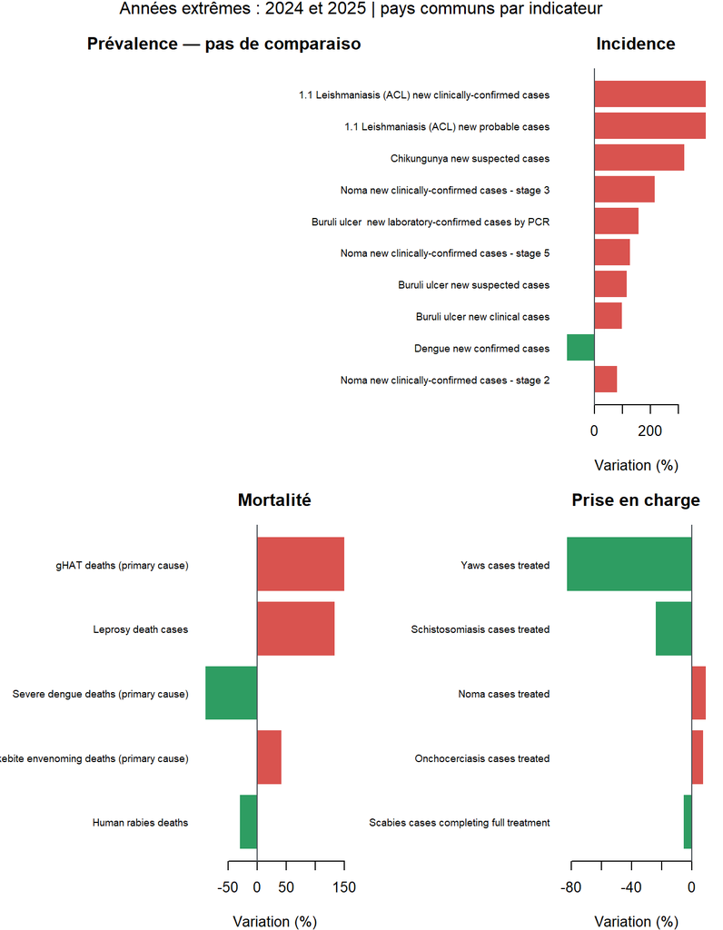

## 3.4 Interprétation par domaine

- **Prévalence** : le fichier présente des nombres de cas et des catégories de cas. Une prévalence (cas / population) exige une population de référence et une définition de période.
- **Incidence** : les indicateurs de nouveaux cas peuvent décrire l’évolution des notifications. Les taux d’incidence exigent une population à risque ou un dénominateur adéquat.
- **Mortalité** : les décès déclarés sont présentés par indicateur. Un taux de mortalité exige les populations correspondantes ; une létalité nécessite des cas et décès comparables pour la même maladie, période et population.
- **Prise en charge** : les nombres de personnes traitées ou orientées sont décrits. La couverture du traitement exige le nombre de personnes éligibles comme dénominateur.

# 4 C. Profil pays

Le profil peut être filtré en modifiant le paramètre `country` dans l’en-tête YAML. La valeur `all` affiche la couverture de tous les pays ; un nom de pays affiche son détail.

Indicateurs numériques disponibles par pays et année

| country | year | indicateurs | domaines |
| --- | --- | --- | --- |
| Angola | 2025 | 21 | Incidence, Mortalité, Prevalence, Prise en charge |
| Benin | 2024 | 15 | Incidence, Prevalence |
| Benin | 2025 | 14 | Incidence, Prevalence |
| Botswana | 2024 | 9 | Incidence, Mortalité, Prevalence |
| Botswana | 2025 | 9 | Incidence, Mortalité, Prevalence |
| Burkina Faso | 2024 | 21 | Incidence, Mortalité, Prevalence, Prise en charge |
| Burkina Faso | 2025 | 27 | Incidence, Mortalité, Prevalence, Prise en charge |
| Burundi | 2024 | 21 | Incidence, Mortalité, Prevalence, Prise en charge |
| Burundi | 2025 | 22 | Incidence, Mortalité, Prevalence, Prise en charge |
| Cabo Verde | 2024 | 13 | Incidence, Mortalité, Prevalence |
| Cabo Verde | 2025 | 15 | Incidence, Mortalité, Prevalence, Prise en charge |
| Cameroon | 2024 | 28 | Incidence, Mortalité, Prevalence, Prise en charge |
| Cameroon | 2025 | 5 | Incidence, Mortalité, Prise en charge |
| Chad | 2024 | 3 | Incidence |
| Chad | 2025 | 4 | Incidence, Mortalité |
| Congo | 2024 | 10 | Incidence, Mortalité, Prise en charge |
| Congo | 2025 | 13 | Incidence, Mortalité, Prevalence, Prise en charge |
| Côte d’Ivoire | 2024 | 1 | Incidence |
| Democratic Republic of the Congo | 2024 | 24 | Incidence, Mortalité, Prevalence, Prise en charge |
| Democratic Republic of the Congo | 2025 | 29 | Incidence, Mortalité, Prevalence, Prise en charge |
| Eritrea | 2024 | 13 | Incidence, Mortalité, Prevalence |
| Eritrea | 2025 | 16 | Incidence, Mortalité, Prevalence, Prise en charge |
| Eswatini | 2024 | 16 | Incidence, Mortalité, Prevalence, Prise en charge |
| Eswatini | 2025 | 17 | Incidence, Mortalité, Prevalence, Prise en charge |
| Ethiopia | 2024 | 11 | Incidence, Mortalité, Prevalence, Prise en charge |
| Ethiopia | 2025 | 15 | Incidence, Mortalité, Prevalence, Prise en charge |
| Gabon | 2024 | 8 | Incidence, Mortalité, Prevalence |
| Gabon | 2025 | 15 | Incidence, Mortalité, Prevalence |
| Gambia | 2024 | 3 | Incidence, Prevalence |
| Ghana | 2024 | 6 | Incidence, Prevalence |
| Ghana | 2025 | 26 | Incidence, Mortalité, Prevalence, Prise en charge |
| Guinea | 2024 | 27 | Incidence, Mortalité, Prevalence, Prise en charge |
| Guinea-Bissau | 2024 | 14 | Incidence, Mortalité, Prevalence, Prise en charge |
| Kenya | 2024 | 1 | Prevalence |
| Kenya | 2025 | 10 | Incidence, Mortalité, Prevalence |
| Lesotho | 2024 | 10 | Incidence, Mortalité, Prevalence, Prise en charge |
| Lesotho | 2025 | 14 | Incidence, Mortalité, Prevalence, Prise en charge |
| Liberia | 2024 | 22 | Incidence, Mortalité, Prevalence, Prise en charge |
| Liberia | 2025 | 27 | Incidence, Mortalité, Prevalence, Prise en charge |
| Mali | 2025 | 6 | Incidence, Mortalité |
| Mauritania | 2024 | 21 | Incidence, Mortalité, Prevalence |
| Mauritius | 2025 | 8 | Incidence, Mortalité, Prevalence |
| Mozambique | 2024 | 11 | Incidence, Mortalité, Prevalence, Prise en charge |
| Mozambique | 2025 | 9 | Incidence, Mortalité, Prevalence, Prise en charge |
| Namibia | 2024 | 14 | Incidence, Mortalité, Prevalence |
| Namibia | 2025 | 13 | Incidence, Mortalité, Prevalence, Prise en charge |
| Niger | 2024 | 3 | Incidence, Prevalence |
| Niger | 2025 | 13 | Incidence, Mortalité, Prevalence |
| Nigeria | 2024 | 22 | Incidence, Mortalité, Prevalence, Prise en charge |
| Nigeria | 2025 | 24 | Incidence, Mortalité, Prevalence, Prise en charge |
| Senegal | 2024 | 44 | Incidence, Mortalité, Prevalence, Prise en charge |
| Senegal | 2025 | 39 | Incidence, Mortalité, Prevalence, Prise en charge |
| Sierra Leone | 2025 | 5 | Incidence, Mortalité |
| South Africa | 2024 | 4 | Incidence, Prevalence |
| South Africa | 2025 | 3 | Incidence, Prevalence |
| South Sudan | 2024 | 1 | Incidence |
| South Sudan | 2025 | 13 | Incidence, Mortalité, Prevalence, Prise en charge |
| Togo | 2024 | 14 | Incidence, Mortalité, Prevalence |
| Togo | 2025 | 48 | Incidence, Mortalité, Prevalence, Prise en charge |
| Uganda | 2024 | 13 | Incidence, Mortalité, Prevalence, Prise en charge |
| Uganda | 2025 | 10 | Incidence, Mortalité, Prevalence, Prise en charge |
| United Republic of Tanzania | 2024 | 4 | Incidence |
| United Republic of Tanzania | 2025 | 4 | Incidence |
| Zimbabwe | 2024 | 21 | Incidence, Mortalité, Prevalence, Prise en charge |
| Zimbabwe | 2025 | 7 | Incidence, Mortalité, Prise en charge |

# 5 Qualité et limites des données

Contrôles de couverture

| Mesure | Valeur |
| --- | --- |
| Lignes dans la table source | 6087 |
| Année manquante | 0 |
| Pays manquant | 0 |
| Code indicateur manquant | 0 |
| Valeur numérique manquante (hors endémicité) | 0 |
| Lignes d’endémicité | 1881 |
| Pays distincts | 45 |
| Indicateurs distincts | 111 |

Les comparaisons sont descriptives et ne démontrent pas à elles seules une hausse ou une baisse réelle de transmission. Les changements de complétude, de surveillance, de définition de cas ou de source doivent être examinés avant toute conclusion programmatique. Les changements basés sur peu de pays sont particulièrement fragiles ; le paramètre `minimum_common_countries` permet d’exiger davantage de pays pour les tableaux par domaine.

## 5.1 Paramètres à adapter

Dans l’en-tête YAML, vous pouvez modifier : `source` (`GNARF` ou `GHO` selon les tables présentes dans SQLite), `disease` (maladie du heatmap, ou `all`), `period` (année rapportée pour l’endémicité, ou `latest`), `year` (année pour les analyses numériques, ou `latest`), `country` (pays du profil, ou `all`) et `minimum_common_countries` (seuil de pays communs aux deux années).